# Daily Options Trade Planning

Adrian Coles

2022-04-04

# Likely Market Direction

**Opening Bell**

**Reference Price:** 4545.86

**Opening Price:** 4547.97

**Opening Gap:** 0.05%

**Planned Economic or Geopolitical Event That Can Cause Whipsaw:** Yes  
**Note:** A gap in this direction and of this magnitude suggests that there is approximately **76%** chance of the market closing in the **green** today

*(98% Credible Interval: [0.72%,0.8%]) [377].*

**Closing Bell**

**Closing Price:** 4582.64

**Actual Percent Change at Close:** 0.81%

**Was My Directional Prediction Correct?:** Yes. My prediction has been correct 90% of the time since 18MAR2022.

**Were My Initial Strikes Breached:** No.

**Weak Side Offensive Adjustments:** No, weak side adjustment were not made. However, my predicted direction of market close was correct, so it would have been safe to make weak side adjustments.

**ROI:** 11.5%

**Closing Diary**

- Implied volatility was very low today, so it was hard to get any worthwhile premium using my data-driven method. So I deviated from my historical data-driven strategy and went w/ 10 delta short strikes which gives a sense of the day’s risk profile at the time of trade entry.
- I set it at about 10AM and didn’t touch the trade again for the rest of the day. I ended the day in the green.
- I’ve decided to purchase data from the CBOE to back test a 10delta strategy over the last year or so. My primary question is how well does a 10 delta selection align with P(Max Profit) over some historical time period. These data are expensive so I won’t have 25 years of data similar to the data on SPX that I’m able to freely obtain.

# Suggested Initial Strikes for Today

My initial strike suggestions are provided in the table below.They are partly based on my objective assumption about the market’s direction today.  
**Note:** Method 3 strikes are user-defined.

| Method | MP Strikes | MP % Change | P(Max Profit) | ML Strikes | ML % Change | P(< Max Loss) |
| --- | --- | --- | --- | --- | --- | --- |
| Method 1: Short Put | 4491 | -1.2 | 0.9 | 4473 | -1.6 | 0.95 |
| Method 1: Short Call | 4610 | 1.4 | 0.91 | 4623 | 1.7 | 0.95 |
| Method 3: Short Put | 4520 | -0.57 | 0.75 | 4505 | -0.9 | 0.85 |
| Method 3: Short Call | 4590 | 0.97 | 0.82 | 4605 | 1.3 | 0.89 |

# Daily Trade Tracker

This section records today’s trading activity.

- Day of Week: Monday
- Was a trade made today?: Yes

**Positioning My Battleship:**

- Time: ~10:00AM
- Type: Iron Condor
- Initial Short Put Strike: 4520
- Initial Short Call Strike: 4590
- Width of Wings: 15

**Monitoring My Battleship:**

- Current Strike Range (% Change): [ -0.57, 0.97 ]
- Current Strikes: [ 4520, 4590 ]
- Break Even Points: [4518.45, 4591.55]

# Evaluating the Probability of Weak Side Adjustments

## Marginal Probabilities

### Market Moving Up (adjust floor):

- **Probability of Max Profit:** P(Closing Above 4510) = 0.9

### Market Moving Down (adjust ceiling):

- **Probability of Max Profit:** P(Closing Below 4609) = 0.9

**Tracking Data Driven Weak Side Hedging:**

- Adjustments Made: No
- Number of Adjustments Made: 0
- Adjusted Short Put Strike:
- Adjusted Short Call Strike:
- Notes About Today’s Adjustments
  - Adjustment 1:

# Daily P/L

- Number of Contracts: 1
- Initial Premium Collected (per contract): 1.55
- Additional Premium Collected (per contract): 0
- Total Premium Collected (per contract): 1.55
- Buy Back Price (per contract): 0
- Opening Trade ROI: 11.5%
- ROI after Adjustments: 11.5%
- **Final P/L at Close/Expiration: $155**
- **Final ROI at Close/Expiration: 11.5%**

# Research and Insights

### Understanding the Nature of the S&P 500

#### Distribution of Percent Change at Close

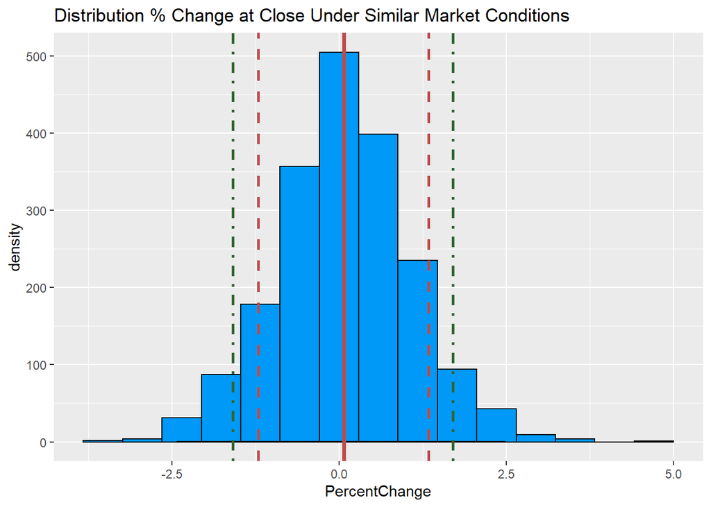

```
## [1] "Sample Size: 1948"
```

```
## [1] "Max Profit Call Side: 1.34% (90% Chance)"
```

```
## [1] "Max Loss Call Side: 1.7% (5% Chance)"
```

```
## [1] "Max Profit Put Side: -1.21% (90% Chance)"
```

```
## [1] "Max Loss Put Side: -1.59% (5% Chance)"
```

**Insights from Visualizing These Data**

#### Distribution of Daily Range

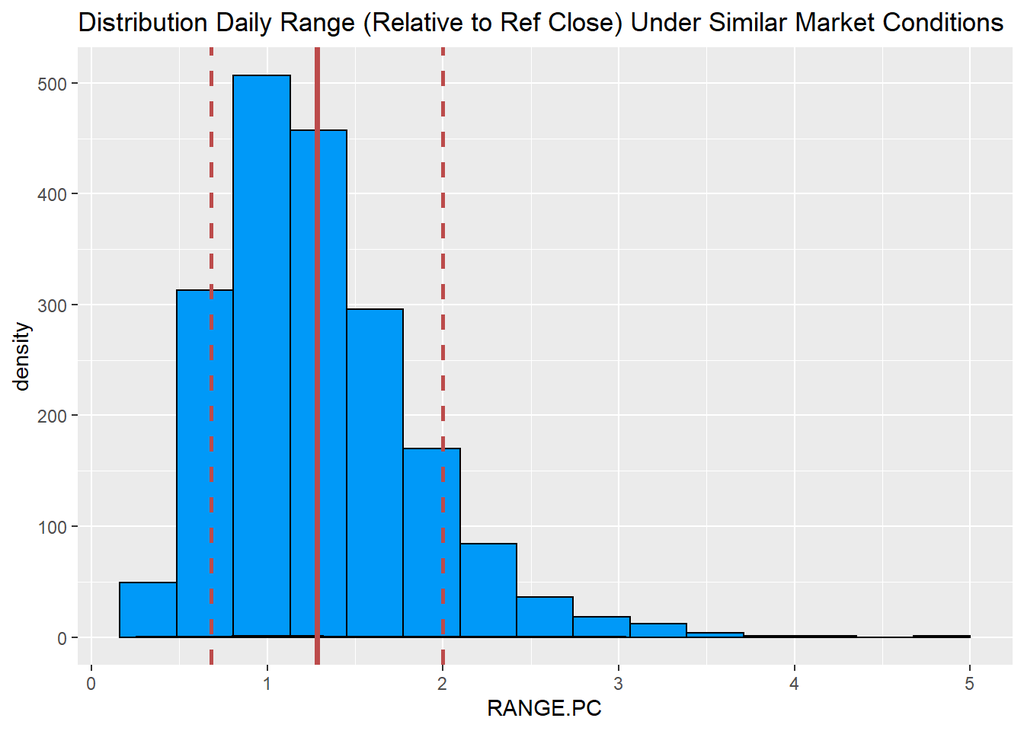

```
## [1] "Five Number Summary :"
```

```
##    Min. 1st Qu.  Median    Mean 3rd Qu.    Max.
##   0.248   0.887   1.195   1.282   1.568   4.764
```

```
## [1] "SD = 0.549"
```

**Insights from Visualizing These Data**

#### Distribution of Daily Range of Close to Low (Set New Ceiling)

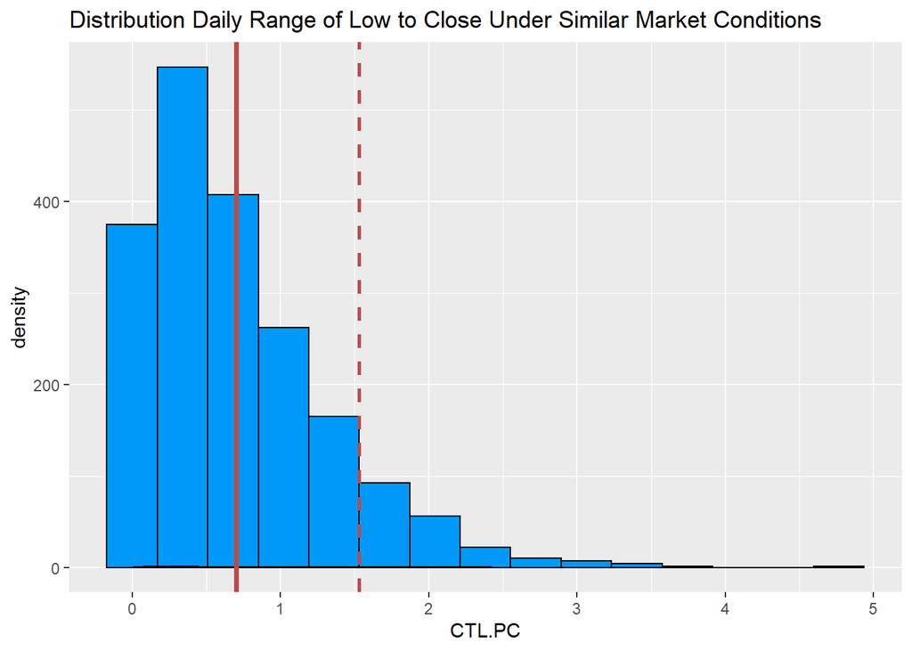

```
## [1] "Five Number Summary :"
```

```
##    Min. 1st Qu.  Median    Mean 3rd Qu.    Max.
##  0.0000  0.2440  0.5570  0.7008  1.0020  4.7640
```

```
## [1] "90th Percentile = 1.528"
```

**Insights from Visualizing These Data**

#### Distribution of Daily Range of Close to High (Set New Floor)

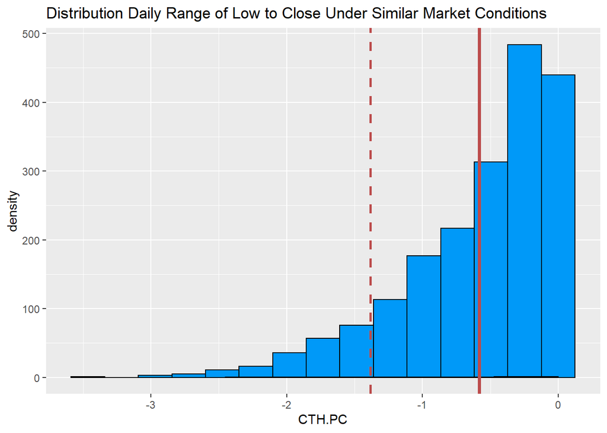

```
## [1] "Five Number Summary :"
```

```
##    Min. 1st Qu.  Median    Mean 3rd Qu.    Max.
## -3.4640 -0.8770 -0.4080 -0.5814 -0.1460  0.0000
```

```
## [1] "10th Percentile = -1.383"
```

**Insights from Visualizing These Data**

# Today’s Basic Trading Profile

- **Capital Deployed Each Trade:** ~5%
- **Target ROI:** 23% (relative to initial put and call spread max loss)
- **Initial Short Strike Selection:** 10 $\Delta$
- **Offensive Strategy:** High probability initial strikes and high probability intra-day adjustments ($\ge 90$%)
- **General Defensive Strategy:**
  - Reduce risk of max loss by using 15 pt wide strikes [P(Max Profit)$\ge$ 0.9 and P(Max Loss)$\le$ 0.05]
  - Don’t attempt to move breached positions. Just let the probabilities play themselves out.
  - Dampen losses from breached positions via weak side hedging.
- **Bi-Weekly Deposits:** $500
- **Fail Safe:** Capital < 1/2 of total deposits
- **Expected Annual Performance of This Profile (from simulation study):**
  - Expected Number of Losses: 15
  - Expected Number of Max Losses: 7 to 8
  - P(Losing Year) ~ 0
  - P(Triggering Fail Safe) ~ 0
  - Expected Annual Return: 241%